# Risk Factor Analysis

## Outcome Variable

**Outcome Variable:** whz

## Predictor Variables

**Intervention Variable:** exclfeed6

**Adjustment Set:**

- arm
- sex
- W_mage
- meducyrs
- feducyrs
- hhwealth_quart
- hfoodsec
- W_mhtcm
- vagbrth
- W_gagebrth
- W_birthwt
- W_birthlen
- W_nrooms
- W_nchldlt5
- month
- brthmon
- W_parity
- impfloor
- impsan
- safeh20
- delta_W_mage
- delta_meducyrs
- delta_feducyrs
- delta_hhwealth_quart
- delta_hfoodsec
- delta_W_mhtcm
- delta_vagbrth
- delta_W_gagebrth
- delta_W_birthwt
- delta_W_birthlen
- delta_W_nrooms
- delta_W_nchldlt5
- delta_month
- delta_brthmon
- delta_W_parity
- delta_impfloor
- delta_impsan
- delta_safeh20

## Stratifying Variables

The analysis was stratified on these variable(s):

- agecat
- studyid
- country

## Data Summary

| agecat | studyid | country | exclfeed6 | n_cell | n |
| --- | --- | --- | --- | --- | --- |
| Birth | ki0047075b-MAL-ED | BANGLADESH | 1 | 53 | 219 |
| Birth | ki0047075b-MAL-ED | BANGLADESH | 0 | 166 | 219 |
| Birth | ki0047075b-MAL-ED | BRAZIL | 1 | 11 | 168 |
| Birth | ki0047075b-MAL-ED | BRAZIL | 0 | 157 | 168 |
| Birth | ki0047075b-MAL-ED | INDIA | 1 | 5 | 187 |
| Birth | ki0047075b-MAL-ED | INDIA | 0 | 182 | 187 |
| Birth | ki0047075b-MAL-ED | NEPAL | 1 | 11 | 165 |
| Birth | ki0047075b-MAL-ED | NEPAL | 0 | 154 | 165 |
| Birth | ki0047075b-MAL-ED | PERU | 1 | 10 | 249 |
| Birth | ki0047075b-MAL-ED | PERU | 0 | 239 | 249 |
| Birth | ki0047075b-MAL-ED | SOUTH AFRICA | 1 | 0 | 209 |
| Birth | ki0047075b-MAL-ED | SOUTH AFRICA | 0 | 209 | 209 |
| Birth | ki0047075b-MAL-ED | TANZANIA, UNITED REPUBLIC OF | 1 | 1 | 115 |
| Birth | ki0047075b-MAL-ED | TANZANIA, UNITED REPUBLIC OF | 0 | 114 | 115 |
| Birth | ki1000108-CMC-V-BCS-2002 | INDIA | 1 | 7 | 7 |
| Birth | ki1000108-CMC-V-BCS-2002 | INDIA | 0 | 0 | 7 |
| Birth | ki1000108-IRC | INDIA | 1 | 0 | 12 |
| Birth | ki1000108-IRC | INDIA | 0 | 12 | 12 |
| Birth | ki1000109-EE | PAKISTAN | 1 | 0 | 1 |
| Birth | ki1000109-EE | PAKISTAN | 0 | 1 | 1 |
| Birth | ki1000304b-SAS-CompFeed | INDIA | 1 | 45 | 47 |
| Birth | ki1000304b-SAS-CompFeed | INDIA | 0 | 2 | 47 |
| Birth | ki1101329-Keneba | GAMBIA | 1 | 451 | 1336 |
| Birth | ki1101329-Keneba | GAMBIA | 0 | 885 | 1336 |
| Birth | kiGH5241-JiVitA-3 | BANGLADESH | 1 | 12371 | 15420 |
| Birth | kiGH5241-JiVitA-3 | BANGLADESH | 0 | 3049 | 15420 |
| Birth | kiGH5241-JiVitA-4 | BANGLADESH | 1 | 519 | 633 |
| Birth | kiGH5241-JiVitA-4 | BANGLADESH | 0 | 114 | 633 |
| 6 months | ki0047075b-MAL-ED | BANGLADESH | 1 | 57 | 235 |
| 6 months | ki0047075b-MAL-ED | BANGLADESH | 0 | 178 | 235 |

[output cut: 64 more lines]

The following strata were considered:

- agecat: 24 months, studyid: ki0047075b-MAL-ED, country: BANGLADESH
- agecat: 24 months, studyid: ki0047075b-MAL-ED, country: BRAZIL
- agecat: 24 months, studyid: ki0047075b-MAL-ED, country: INDIA
- agecat: 24 months, studyid: ki0047075b-MAL-ED, country: NEPAL
- agecat: 24 months, studyid: ki0047075b-MAL-ED, country: PERU
- agecat: 24 months, studyid: ki0047075b-MAL-ED, country: SOUTH AFRICA
- agecat: 24 months, studyid: ki0047075b-MAL-ED, country: TANZANIA, UNITED REPUBLIC OF
- agecat: 24 months, studyid: ki1000108-CMC-V-BCS-2002, country: INDIA
- agecat: 24 months, studyid: ki1000108-IRC, country: INDIA
- agecat: 24 months, studyid: ki1017093b-PROVIDE, country: BANGLADESH
- agecat: 24 months, studyid: ki1101329-Keneba, country: GAMBIA
- agecat: 24 months, studyid: ki1113344-GMS-Nepal, country: NEPAL
- agecat: 24 months, studyid: ki1148112-LCNI-5, country: MALAWI
- agecat: 24 months, studyid: kiGH5241-JiVitA-3, country: BANGLADESH
- agecat: 24 months, studyid: kiGH5241-JiVitA-4, country: BANGLADESH
- agecat: 6 months, studyid: ki0047075b-MAL-ED, country: BANGLADESH
- agecat: 6 months, studyid: ki0047075b-MAL-ED, country: BRAZIL
- agecat: 6 months, studyid: ki0047075b-MAL-ED, country: INDIA
- agecat: 6 months, studyid: ki0047075b-MAL-ED, country: NEPAL
- agecat: 6 months, studyid: ki0047075b-MAL-ED, country: PERU
- agecat: 6 months, studyid: ki0047075b-MAL-ED, country: SOUTH AFRICA
- agecat: 6 months, studyid: ki0047075b-MAL-ED, country: TANZANIA, UNITED REPUBLIC OF
- agecat: 6 months, studyid: ki1000108-CMC-V-BCS-2002, country: INDIA
- agecat: 6 months, studyid: ki1000108-IRC, country: INDIA
- agecat: 6 months, studyid: ki1000109-EE, country: PAKISTAN
- agecat: 6 months, studyid: ki1000304b-SAS-CompFeed, country: INDIA
- agecat: 6 months, studyid: ki1000304b-SAS-FoodSuppl, country: INDIA
- agecat: 6 months, studyid: ki1017093b-PROVIDE, country: BANGLADESH
- agecat: 6 months, studyid: ki1101329-Keneba, country: GAMBIA
- agecat: 6 months, studyid: ki1113344-GMS-Nepal, country: NEPAL
- agecat: 6 months, studyid: ki1148112-LCNI-5, country: MALAWI
- agecat: 6 months, studyid: kiGH5241-JiVitA-3, country: BANGLADESH
- agecat: 6 months, studyid: kiGH5241-JiVitA-4, country: BANGLADESH
- agecat: Birth, studyid: ki0047075b-MAL-ED, country: BANGLADESH
- agecat: Birth, studyid: ki0047075b-MAL-ED, country: BRAZIL
- agecat: Birth, studyid: ki0047075b-MAL-ED, country: INDIA
- agecat: Birth, studyid: ki0047075b-MAL-ED, country: NEPAL
- agecat: Birth, studyid: ki0047075b-MAL-ED, country: PERU
- agecat: Birth, studyid: ki0047075b-MAL-ED, country: SOUTH AFRICA
- agecat: Birth, studyid: ki0047075b-MAL-ED, country: TANZANIA, UNITED REPUBLIC OF
- agecat: Birth, studyid: ki1000108-CMC-V-BCS-2002, country: INDIA
- agecat: Birth, studyid: ki1000108-IRC, country: INDIA
- agecat: Birth, studyid: ki1000109-EE, country: PAKISTAN
- agecat: Birth, studyid: ki1000304b-SAS-CompFeed, country: INDIA
- agecat: Birth, studyid: ki1101329-Keneba, country: GAMBIA
- agecat: Birth, studyid: kiGH5241-JiVitA-3, country: BANGLADESH
- agecat: Birth, studyid: kiGH5241-JiVitA-4, country: BANGLADESH

### Dropped Strata

Some strata were dropped due to rare outcomes:

- agecat: Birth, studyid: ki0047075b-MAL-ED, country: SOUTH AFRICA
- agecat: Birth, studyid: ki0047075b-MAL-ED, country: TANZANIA, UNITED REPUBLIC OF
- agecat: Birth, studyid: ki1000108-CMC-V-BCS-2002, country: INDIA
- agecat: Birth, studyid: ki1000108-IRC, country: INDIA
- agecat: Birth, studyid: ki1000109-EE, country: PAKISTAN
- agecat: Birth, studyid: ki1000304b-SAS-CompFeed, country: INDIA
- agecat: 6 months, studyid: ki0047075b-MAL-ED, country: SOUTH AFRICA
- agecat: 6 months, studyid: ki0047075b-MAL-ED, country: TANZANIA, UNITED REPUBLIC OF
- agecat: 6 months, studyid: ki1000108-CMC-V-BCS-2002, country: INDIA
- agecat: 6 months, studyid: ki1000108-IRC, country: INDIA
- agecat: 6 months, studyid: ki1000304b-SAS-FoodSuppl, country: INDIA
- agecat: 24 months, studyid: ki0047075b-MAL-ED, country: SOUTH AFRICA
- agecat: 24 months, studyid: ki0047075b-MAL-ED, country: TANZANIA, UNITED REPUBLIC OF
- agecat: 24 months, studyid: ki1000108-CMC-V-BCS-2002, country: INDIA
- agecat: 24 months, studyid: ki1000108-IRC, country: INDIA

## Methods Detail

We’re interested in the causal parameters $E[Y_a]$ for all values of $a \in \mathcal{A}$. These parameters represent the mean outcome if, possibly contrary to fact, we intervened to set all units to have $A=a$. Under the randomization and positivity assumptions, these are identified by the statistical parameters $\psi_a=E_W[E_{Y|A,W}(Y|A=a,W)]$. In addition, we’re interested in the mean of $Y$, $E[Y]$ under no intervention (the observed mean). We will estimate these parameters by using SuperLearner to fit the relevant likelihood factors – $E_{Y|A,W}(Y|A=a,W)$ and $p(A=a|W)$, and then updating our likelihood fit using a joint TMLE.

For unadjusted analyses ($W=\{\}$), initial likelihoods were estimated using Lrnr_glm to estimate the simple $E(Y|A)$ and Lrnr_mean to estimate $p(A)$. For adjusted analyses, a small library containing Lrnr_glmnet, Lrnr_xgboost, and Lrnr_mean was used.

Having estimated these parameters, we will then use the delta method to estimate relative risks and attributable risks relative to a prespecified baseline level of $A$.

# Results Detail

## Results Plots

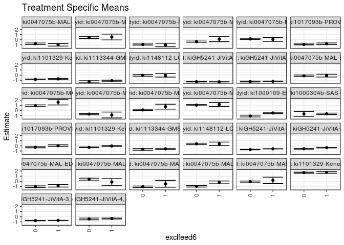

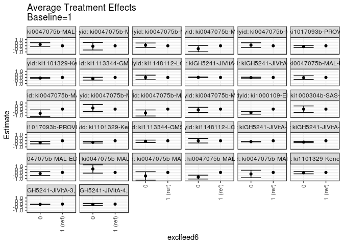

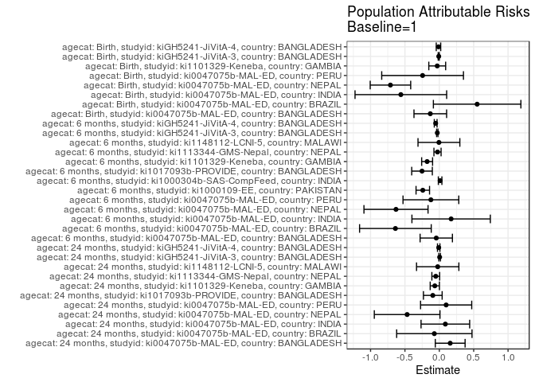

## Results Table

### Parameter: TSM

| agecat | studyid | country | intervention_level | baseline_level | estimate | ci_lower | ci_upper |
| --- | --- | --- | --- | --- | --- | --- | --- |
| Birth | ki0047075b-MAL-ED | BANGLADESH | 1 | NA | -0.8613342 | -1.1229267 | -0.5997416 |
| Birth | ki0047075b-MAL-ED | BANGLADESH | 0 | NA | -1.0519162 | -1.2202184 | -0.8836139 |
| Birth | ki0047075b-MAL-ED | BRAZIL | 1 | NA | -0.1429685 | -0.7908589 | 0.5049219 |
| Birth | ki0047075b-MAL-ED | BRAZIL | 0 | NA | 0.4202943 | 0.2282799 | 0.6123087 |
| Birth | ki0047075b-MAL-ED | INDIA | 1 | NA | -0.4840000 | -1.1529993 | 0.1849993 |
| Birth | ki0047075b-MAL-ED | INDIA | 0 | NA | -1.0589560 | -1.2040739 | -0.9138382 |
| Birth | ki0047075b-MAL-ED | NEPAL | 1 | NA | -0.2117708 | -0.4888710 | 0.0653295 |
| Birth | ki0047075b-MAL-ED | NEPAL | 0 | NA | -0.9708799 | -1.1162392 | -0.8255206 |
| Birth | ki0047075b-MAL-ED | PERU | 1 | NA | 0.2002020 | -0.4029748 | 0.8033787 |
| Birth | ki0047075b-MAL-ED | PERU | 0 | NA | -0.0551940 | -0.1750584 | 0.0646705 |
| Birth | ki1101329-Keneba | GAMBIA | 1 | NA | 1.7207601 | 1.5657110 | 1.8758093 |
| Birth | ki1101329-Keneba | GAMBIA | 0 | NA | 1.6775211 | 1.5774262 | 1.7776161 |
| Birth | kiGH5241-JiVitA-3 | BANGLADESH | 1 | NA | -0.7151646 | -0.7364481 | -0.6938810 |
| Birth | kiGH5241-JiVitA-3 | BANGLADESH | 0 | NA | -0.7516749 | -0.7902594 | -0.7130904 |
| Birth | kiGH5241-JiVitA-4 | BANGLADESH | 1 | NA | -0.3617890 | -0.4541506 | -0.2694273 |
| Birth | kiGH5241-JiVitA-4 | BANGLADESH | 0 | NA | -0.4317213 | -0.5984671 | -0.2649755 |
| 6 months | ki0047075b-MAL-ED | BANGLADESH | 1 | NA | -0.1021510 | -0.3701819 | 0.1658798 |
| 6 months | ki0047075b-MAL-ED | BANGLADESH | 0 | NA | -0.1379630 | -0.2899800 | 0.0140539 |
| 6 months | ki0047075b-MAL-ED | BRAZIL | 1 | NA | 1.6104170 | 1.0780176 | 2.1428163 |
| 6 months | ki0047075b-MAL-ED | BRAZIL | 0 | NA | 0.9223422 | 0.7514348 | 1.0932497 |
| 6 months | ki0047075b-MAL-ED | INDIA | 1 | NA | -0.8747222 | -1.4459598 | -0.3034846 |
| 6 months | ki0047075b-MAL-ED | INDIA | 0 | NA | -0.6983112 | -0.8261224 | -0.5705000 |
| 6 months | ki0047075b-MAL-ED | NEPAL | 1 | NA | 0.7468511 | 0.2725293 | 1.2211729 |
| 6 months | ki0047075b-MAL-ED | NEPAL | 0 | NA | 0.1128452 | -0.0230316 | 0.2487221 |
| 6 months | ki0047075b-MAL-ED | PERU | 1 | NA | 1.1779110 | 0.7754620 | 1.5803601 |
| 6 months | ki0047075b-MAL-ED | PERU | 0 | NA | 1.0521724 | 0.9247619 | 1.1795828 |
| 6 months | ki1000109-EE | PAKISTAN | 1 | NA | -0.4810148 | -0.6190044 | -0.3430252 |
| 6 months | ki1000109-EE | PAKISTAN | 0 | NA | -1.0782031 | -1.2573838 | -0.8990225 |
| 6 months | ki1000304b-SAS-CompFeed | INDIA | 1 | NA | -0.6465859 | -0.7848454 | -0.5083265 |
| 6 months | ki1000304b-SAS-CompFeed | INDIA | 0 | NA | -0.6556227 | -1.1386877 | -0.1725576 |
| 6 months | ki1017093b-PROVIDE | BANGLADESH | 1 | NA | 0.0431550 | -0.1249185 | 0.2112285 |
| 6 months | ki1017093b-PROVIDE | BANGLADESH | 0 | NA | -0.2703265 | -0.3674078 | -0.1732453 |
| 6 months | ki1101329-Keneba | GAMBIA | 1 | NA | -0.0224791 | -0.1192620 | 0.0743038 |
| 6 months | ki1101329-Keneba | GAMBIA | 0 | NA | -0.2815004 | -0.3441224 | -0.2188783 |
| 6 months | ki1113344-GMS-Nepal | NEPAL | 1 | NA | -0.5753782 | -0.6784362 | -0.4723202 |
| 6 months | ki1113344-GMS-Nepal | NEPAL | 0 | NA | -0.6689384 | -0.8390018 | -0.4988749 |
| 6 months | ki1148112-LCNI-5 | MALAWI | 1 | NA | 0.3983533 | 0.0574230 | 0.7392837 |
| 6 months | ki1148112-LCNI-5 | MALAWI | 0 | NA | 0.3956955 | 0.2689067 | 0.5224842 |
| 6 months | kiGH5241-JiVitA-3 | BANGLADESH | 1 | NA | -0.5638929 | -0.5853110 | -0.5424748 |
| 6 months | kiGH5241-JiVitA-3 | BANGLADESH | 0 | NA | -0.7114630 | -0.7532174 | -0.6697086 |
| 6 months | kiGH5241-JiVitA-4 | BANGLADESH | 1 | NA | -0.3442580 | -0.3906754 | -0.2978406 |
| 6 months | kiGH5241-JiVitA-4 | BANGLADESH | 0 | NA | -0.5631488 | -0.6396986 | -0.4865991 |
| 24 months | ki0047075b-MAL-ED | BANGLADESH | 1 | NA | -0.9899497 | -1.2436539 | -0.7362455 |
| 24 months | ki0047075b-MAL-ED | BANGLADESH | 0 | NA | -0.7813875 | -0.9213733 | -0.6414017 |
| 24 months | ki0047075b-MAL-ED | BRAZIL | 1 | NA | 0.5191131 | -0.0474834 | 1.0857096 |
| 24 months | ki0047075b-MAL-ED | BRAZIL | 0 | NA | 0.4379480 | 0.2225050 | 0.6533909 |
| 24 months | ki0047075b-MAL-ED | INDIA | 1 | NA | -1.0270000 | -1.3699520 | -0.6840480 |
| 24 months | ki0047075b-MAL-ED | INDIA | 0 | NA | -0.9370776 | -1.0552061 | -0.8189492 |
| 24 months | ki0047075b-MAL-ED | NEPAL | 1 | NA | 0.0976579 | -0.3902379 | 0.5855537 |
| 24 months | ki0047075b-MAL-ED | NEPAL | 0 | NA | -0.3772087 | -0.4945595 | -0.2598580 |
| 24 months | ki0047075b-MAL-ED | PERU | 1 | NA | 0.0437500 | -0.3245346 | 0.4120346 |
| 24 months | ki0047075b-MAL-ED | PERU | 0 | NA | 0.1471842 | 0.0256636 | 0.2687048 |
| 24 months | ki1017093b-PROVIDE | BANGLADESH | 1 | NA | -0.7931828 | -0.9492322 | -0.6371333 |
| 24 months | ki1017093b-PROVIDE | BANGLADESH | 0 | NA | -0.9186776 | -1.0148032 | -0.8225520 |
| 24 months | ki1101329-Keneba | GAMBIA | 1 | NA | -0.7378431 | -0.8198764 | -0.6558097 |
| 24 months | ki1101329-Keneba | GAMBIA | 0 | NA | -0.8365241 | -0.8982808 | -0.7747675 |
| 24 months | ki1113344-GMS-Nepal | NEPAL | 1 | NA | -1.0853137 | -1.1842270 | -0.9864005 |
| 24 months | ki1113344-GMS-Nepal | NEPAL | 0 | NA | -1.2876967 | -1.4934834 | -1.0819100 |
| 24 months | ki1148112-LCNI-5 | MALAWI | 1 | NA | -0.0536859 | -0.3849790 | 0.2776071 |
| 24 months | ki1148112-LCNI-5 | MALAWI | 0 | NA | -0.0526653 | -0.2158767 | 0.1105460 |
| 24 months | kiGH5241-JiVitA-3 | BANGLADESH | 1 | NA | -1.3039756 | -1.3303844 | -1.2775668 |
| 24 months | kiGH5241-JiVitA-3 | BANGLADESH | 0 | NA | -1.2852163 | -1.3328805 | -1.2375521 |
| 24 months | kiGH5241-JiVitA-4 | BANGLADESH | 1 | NA | -1.2250774 | -1.2622464 | -1.1879085 |
| 24 months | kiGH5241-JiVitA-4 | BANGLADESH | 0 | NA | -1.2599271 | -1.3339921 | -1.1858622 |

### Parameter: E(Y)

| agecat | studyid | country | intervention_level | baseline_level | estimate | ci_lower | ci_upper |
| --- | --- | --- | --- | --- | --- | --- | --- |
| Birth | ki0047075b-MAL-ED | BANGLADESH | NA | NA | -0.9925114 | -1.1346572 | -0.8503656 |
| Birth | ki0047075b-MAL-ED | BRAZIL | NA | NA | 0.4073214 | 0.2229599 | 0.5916830 |
| Birth | ki0047075b-MAL-ED | INDIA | NA | NA | -1.0435829 | -1.1865715 | -0.9005943 |
| Birth | ki0047075b-MAL-ED | NEPAL | NA | NA | -0.9226061 | -1.0630064 | -0.7822058 |
| Birth | ki0047075b-MAL-ED | PERU | NA | NA | -0.0430924 | -0.1600210 | 0.0738362 |
| Birth | ki1101329-Keneba | GAMBIA | NA | NA | 1.6904416 | 1.6057966 | 1.7750867 |
| Birth | kiGH5241-JiVitA-3 | BANGLADESH | NA | NA | -0.7234060 | -0.7433920 | -0.7034200 |
| Birth | kiGH5241-JiVitA-4 | BANGLADESH | NA | NA | -0.3738863 | -0.4580087 | -0.2897638 |
| 6 months | ki0047075b-MAL-ED | BANGLADESH | NA | NA | -0.1464929 | -0.2779745 | -0.0150113 |
| 6 months | ki0047075b-MAL-ED | BRAZIL | NA | NA | 0.9717225 | 0.8073791 | 1.1360658 |
| 6 months | ki0047075b-MAL-ED | INDIA | NA | NA | -0.7028736 | -0.8283047 | -0.5774424 |
| 6 months | ki0047075b-MAL-ED | NEPAL | NA | NA | 0.1167518 | -0.0146454 | 0.2481490 |
| 6 months | ki0047075b-MAL-ED | PERU | NA | NA | 1.0554461 | 0.9322755 | 1.1786167 |
| 6 months | ki1000109-EE | PAKISTAN | NA | NA | -0.7212766 | -0.8346857 | -0.6078675 |
| 6 months | ki1000304b-SAS-CompFeed | INDIA | NA | NA | -0.6348861 | -0.7630511 | -0.5067211 |
| 6 months | ki1017093b-PROVIDE | BANGLADESH | NA | NA | -0.2083706 | -0.2927992 | -0.1239419 |
| 6 months | ki1101329-Keneba | GAMBIA | NA | NA | -0.1997850 | -0.2531586 | -0.1464114 |
| 6 months | ki1113344-GMS-Nepal | NEPAL | NA | NA | -0.6015049 | -0.6892785 | -0.5137313 |
| 6 months | ki1148112-LCNI-5 | MALAWI | NA | NA | 0.3927574 | 0.2737700 | 0.5117448 |
| 6 months | kiGH5241-JiVitA-3 | BANGLADESH | NA | NA | -0.5931801 | -0.6126929 | -0.5736674 |
| 6 months | kiGH5241-JiVitA-4 | BANGLADESH | NA | NA | -0.3971948 | -0.4378192 | -0.3565704 |
| 24 months | ki0047075b-MAL-ED | BANGLADESH | NA | NA | -0.8315789 | -0.9546058 | -0.7085521 |
| 24 months | ki0047075b-MAL-ED | BRAZIL | NA | NA | 0.4466272 | 0.2416144 | 0.6516401 |
| 24 months | ki0047075b-MAL-ED | INDIA | NA | NA | -0.9390848 | -1.0545919 | -0.8235777 |
| 24 months | ki0047075b-MAL-ED | NEPAL | NA | NA | -0.3703084 | -0.4835704 | -0.2570464 |
| 24 months | ki0047075b-MAL-ED | PERU | NA | NA | 0.1430051 | 0.0254144 | 0.2605957 |
| 24 months | ki1017093b-PROVIDE | BANGLADESH | NA | NA | -0.8879412 | -0.9708680 | -0.8050144 |
| 24 months | ki1101329-Keneba | GAMBIA | NA | NA | -0.8032329 | -0.8532842 | -0.7531817 |
| 24 months | ki1113344-GMS-Nepal | NEPAL | NA | NA | -1.1369520 | -1.2269975 | -1.0469065 |
| 24 months | ki1148112-LCNI-5 | MALAWI | NA | NA | -0.0771196 | -0.2204715 | 0.0662323 |
| 24 months | kiGH5241-JiVitA-3 | BANGLADESH | NA | NA | -1.2991319 | -1.3225545 | -1.2757094 |
| 24 months | kiGH5241-JiVitA-4 | BANGLADESH | NA | NA | -1.2337581 | -1.2679680 | -1.1995482 |

### Parameter: ATE

| agecat | studyid | country | intervention_level | baseline_level | estimate | ci_lower | ci_upper |
| --- | --- | --- | --- | --- | --- | --- | --- |
| Birth | ki0047075b-MAL-ED | BANGLADESH | 1 | 1 | 0.0000000 | 0.0000000 | 0.0000000 |
| Birth | ki0047075b-MAL-ED | BANGLADESH | 0 | 1 | -0.1905820 | -0.5022847 | 0.1211207 |
| Birth | ki0047075b-MAL-ED | BRAZIL | 1 | 1 | 0.0000000 | 0.0000000 | 0.0000000 |
| Birth | ki0047075b-MAL-ED | BRAZIL | 0 | 1 | 0.5632628 | -0.1122995 | 1.2388251 |
| Birth | ki0047075b-MAL-ED | INDIA | 1 | 1 | 0.0000000 | 0.0000000 | 0.0000000 |
| Birth | ki0047075b-MAL-ED | INDIA | 0 | 1 | -0.5749560 | -1.2595138 | 0.1096017 |
| Birth | ki0047075b-MAL-ED | NEPAL | 1 | 1 | 0.0000000 | 0.0000000 | 0.0000000 |
| Birth | ki0047075b-MAL-ED | NEPAL | 0 | 1 | -0.7591091 | -1.0726489 | -0.4455693 |
| Birth | ki0047075b-MAL-ED | PERU | 1 | 1 | 0.0000000 | 0.0000000 | 0.0000000 |
| Birth | ki0047075b-MAL-ED | PERU | 0 | 1 | -0.2553959 | -0.8699854 | 0.3591936 |
| Birth | ki1101329-Keneba | GAMBIA | 1 | 1 | 0.0000000 | 0.0000000 | 0.0000000 |
| Birth | ki1101329-Keneba | GAMBIA | 0 | 1 | -0.0432390 | -0.2279956 | 0.1415176 |
| Birth | kiGH5241-JiVitA-3 | BANGLADESH | 1 | 1 | 0.0000000 | 0.0000000 | 0.0000000 |
| Birth | kiGH5241-JiVitA-3 | BANGLADESH | 0 | 1 | -0.0365103 | -0.0766165 | 0.0035959 |
| Birth | kiGH5241-JiVitA-4 | BANGLADESH | 1 | 1 | 0.0000000 | 0.0000000 | 0.0000000 |
| Birth | kiGH5241-JiVitA-4 | BANGLADESH | 0 | 1 | -0.0699323 | -0.2518298 | 0.1119651 |
| 6 months | ki0047075b-MAL-ED | BANGLADESH | 1 | 1 | 0.0000000 | 0.0000000 | 0.0000000 |
| 6 months | ki0047075b-MAL-ED | BANGLADESH | 0 | 1 | -0.0358120 | -0.3452216 | 0.2735976 |
| 6 months | ki0047075b-MAL-ED | BRAZIL | 1 | 1 | 0.0000000 | 0.0000000 | 0.0000000 |
| 6 months | ki0047075b-MAL-ED | BRAZIL | 0 | 1 | -0.6880747 | -1.2471438 | -0.1290056 |
| 6 months | ki0047075b-MAL-ED | INDIA | 1 | 1 | 0.0000000 | 0.0000000 | 0.0000000 |
| 6 months | ki0047075b-MAL-ED | INDIA | 0 | 1 | 0.1764110 | -0.4089505 | 0.7617725 |
| 6 months | ki0047075b-MAL-ED | NEPAL | 1 | 1 | 0.0000000 | 0.0000000 | 0.0000000 |
| 6 months | ki0047075b-MAL-ED | NEPAL | 0 | 1 | -0.6340059 | -1.1271756 | -0.1408361 |
| 6 months | ki0047075b-MAL-ED | PERU | 1 | 1 | 0.0000000 | 0.0000000 | 0.0000000 |
| 6 months | ki0047075b-MAL-ED | PERU | 0 | 1 | -0.1257387 | -0.5477951 | 0.2963177 |
| 6 months | ki1000109-EE | PAKISTAN | 1 | 1 | 0.0000000 | 0.0000000 | 0.0000000 |
| 6 months | ki1000109-EE | PAKISTAN | 0 | 1 | -0.5971883 | -0.8242837 | -0.3700930 |
| 6 months | ki1000304b-SAS-CompFeed | INDIA | 1 | 1 | 0.0000000 | 0.0000000 | 0.0000000 |
| 6 months | ki1000304b-SAS-CompFeed | INDIA | 0 | 1 | -0.0090367 | -0.5362411 | 0.5181676 |
| 6 months | ki1017093b-PROVIDE | BANGLADESH | 1 | 1 | 0.0000000 | 0.0000000 | 0.0000000 |
| 6 months | ki1017093b-PROVIDE | BANGLADESH | 0 | 1 | -0.3134815 | -0.5076880 | -0.1192750 |
| 6 months | ki1101329-Keneba | GAMBIA | 1 | 1 | 0.0000000 | 0.0000000 | 0.0000000 |
| 6 months | ki1101329-Keneba | GAMBIA | 0 | 1 | -0.2590213 | -0.3731528 | -0.1448897 |
| 6 months | ki1113344-GMS-Nepal | NEPAL | 1 | 1 | 0.0000000 | 0.0000000 | 0.0000000 |
| 6 months | ki1113344-GMS-Nepal | NEPAL | 0 | 1 | -0.0935602 | -0.2925682 | 0.1054478 |
| 6 months | ki1148112-LCNI-5 | MALAWI | 1 | 1 | 0.0000000 | 0.0000000 | 0.0000000 |
| 6 months | ki1148112-LCNI-5 | MALAWI | 0 | 1 | -0.0026579 | -0.3666647 | 0.3613489 |
| 6 months | kiGH5241-JiVitA-3 | BANGLADESH | 1 | 1 | 0.0000000 | 0.0000000 | 0.0000000 |
| 6 months | kiGH5241-JiVitA-3 | BANGLADESH | 0 | 1 | -0.1475701 | -0.1928385 | -0.1023016 |
| 6 months | kiGH5241-JiVitA-4 | BANGLADESH | 1 | 1 | 0.0000000 | 0.0000000 | 0.0000000 |
| 6 months | kiGH5241-JiVitA-4 | BANGLADESH | 0 | 1 | -0.2188908 | -0.3069965 | -0.1307851 |
| 24 months | ki0047075b-MAL-ED | BANGLADESH | 1 | 1 | 0.0000000 | 0.0000000 | 0.0000000 |
| 24 months | ki0047075b-MAL-ED | BANGLADESH | 0 | 1 | 0.2085622 | -0.0805306 | 0.4976550 |
| 24 months | ki0047075b-MAL-ED | BRAZIL | 1 | 1 | 0.0000000 | 0.0000000 | 0.0000000 |
| 24 months | ki0047075b-MAL-ED | BRAZIL | 0 | 1 | -0.0811651 | -0.6888042 | 0.5264740 |
| 24 months | ki0047075b-MAL-ED | INDIA | 1 | 1 | 0.0000000 | 0.0000000 | 0.0000000 |
| 24 months | ki0047075b-MAL-ED | INDIA | 0 | 1 | 0.0899224 | -0.2728040 | 0.4526487 |
| 24 months | ki0047075b-MAL-ED | NEPAL | 1 | 1 | 0.0000000 | 0.0000000 | 0.0000000 |
| 24 months | ki0047075b-MAL-ED | NEPAL | 0 | 1 | -0.4748666 | -0.9779107 | 0.0281775 |
| 24 months | ki0047075b-MAL-ED | PERU | 1 | 1 | 0.0000000 | 0.0000000 | 0.0000000 |
| 24 months | ki0047075b-MAL-ED | PERU | 0 | 1 | 0.1034342 | -0.2843812 | 0.4912496 |
| 24 months | ki1017093b-PROVIDE | BANGLADESH | 1 | 1 | 0.0000000 | 0.0000000 | 0.0000000 |
| 24 months | ki1017093b-PROVIDE | BANGLADESH | 0 | 1 | -0.1254948 | -0.3061783 | 0.0551886 |
| 24 months | ki1101329-Keneba | GAMBIA | 1 | 1 | 0.0000000 | 0.0000000 | 0.0000000 |
| 24 months | ki1101329-Keneba | GAMBIA | 0 | 1 | -0.0986811 | -0.2001601 | 0.0027980 |
| 24 months | ki1113344-GMS-Nepal | NEPAL | 1 | 1 | 0.0000000 | 0.0000000 | 0.0000000 |
| 24 months | ki1113344-GMS-Nepal | NEPAL | 0 | 1 | -0.2023830 | -0.4308428 | 0.0260768 |
| 24 months | ki1148112-LCNI-5 | MALAWI | 1 | 1 | 0.0000000 | 0.0000000 | 0.0000000 |
| 24 months | ki1148112-LCNI-5 | MALAWI | 0 | 1 | 0.0010206 | -0.3710164 | 0.3730576 |
| 24 months | kiGH5241-JiVitA-3 | BANGLADESH | 1 | 1 | 0.0000000 | 0.0000000 | 0.0000000 |
| 24 months | kiGH5241-JiVitA-3 | BANGLADESH | 0 | 1 | 0.0187592 | -0.0345023 | 0.0720207 |
| 24 months | kiGH5241-JiVitA-4 | BANGLADESH | 1 | 1 | 0.0000000 | 0.0000000 | 0.0000000 |
| 24 months | kiGH5241-JiVitA-4 | BANGLADESH | 0 | 1 | -0.0348497 | -0.1152285 | 0.0455291 |

### Parameter: PAR

| agecat | studyid | country | intervention_level | baseline_level | estimate | ci_lower | ci_upper |
| --- | --- | --- | --- | --- | --- | --- | --- |
| Birth | ki0047075b-MAL-ED | BANGLADESH | 1 | NA | -0.1311772 | -0.3685001 | 0.1061456 |
| Birth | ki0047075b-MAL-ED | BRAZIL | 1 | NA | 0.5502899 | -0.0861917 | 1.1867715 |
| Birth | ki0047075b-MAL-ED | INDIA | 1 | NA | -0.5595829 | -1.2259702 | 0.1068045 |
| Birth | ki0047075b-MAL-ED | NEPAL | 1 | NA | -0.7108353 | -1.0053645 | -0.4163061 |
| Birth | ki0047075b-MAL-ED | PERU | 1 | NA | -0.2432943 | -0.8377994 | 0.3512107 |
| Birth | ki1101329-Keneba | GAMBIA | 1 | NA | -0.0303185 | -0.1528436 | 0.0922066 |
| Birth | kiGH5241-JiVitA-3 | BANGLADESH | 1 | NA | -0.0082414 | -0.0163470 | -0.0001358 |
| Birth | kiGH5241-JiVitA-4 | BANGLADESH | 1 | NA | -0.0120973 | -0.0445236 | 0.0203290 |
| 6 months | ki0047075b-MAL-ED | BANGLADESH | 1 | NA | -0.0443419 | -0.2794411 | 0.1907574 |
| 6 months | ki0047075b-MAL-ED | BRAZIL | 1 | NA | -0.6386945 | -1.1599028 | -0.1174862 |
| 6 months | ki0047075b-MAL-ED | INDIA | 1 | NA | 0.1718487 | -0.3983856 | 0.7420829 |
| 6 months | ki0047075b-MAL-ED | NEPAL | 1 | NA | -0.6300993 | -1.0962173 | -0.1639813 |
| 6 months | ki0047075b-MAL-ED | PERU | 1 | NA | -0.1224650 | -0.5280940 | 0.2831641 |
| 6 months | ki1000109-EE | PAKISTAN | 1 | NA | -0.2402618 | -0.3385131 | -0.1420105 |
| 6 months | ki1000304b-SAS-CompFeed | INDIA | 1 | NA | 0.0116999 | -0.0141795 | 0.0375792 |
| 6 months | ki1017093b-PROVIDE | BANGLADESH | 1 | NA | -0.2515256 | -0.4014639 | -0.1015872 |
| 6 months | ki1101329-Keneba | GAMBIA | 1 | NA | -0.1773059 | -0.2567831 | -0.0978286 |
| 6 months | ki1113344-GMS-Nepal | NEPAL | 1 | NA | -0.0261267 | -0.0781484 | 0.0258950 |
| 6 months | ki1148112-LCNI-5 | MALAWI | 1 | NA | -0.0055960 | -0.3099088 | 0.2987168 |
| 6 months | kiGH5241-JiVitA-3 | BANGLADESH | 1 | NA | -0.0292872 | -0.0387920 | -0.0197824 |
| 6 months | kiGH5241-JiVitA-4 | BANGLADESH | 1 | NA | -0.0529368 | -0.0730337 | -0.0328399 |
| 24 months | ki0047075b-MAL-ED | BANGLADESH | 1 | NA | 0.1583707 | -0.0583892 | 0.3751307 |
| 24 months | ki0047075b-MAL-ED | BRAZIL | 1 | NA | -0.0724859 | -0.6205548 | 0.4755830 |
| 24 months | ki0047075b-MAL-ED | INDIA | 1 | NA | 0.0879152 | -0.2657473 | 0.4415777 |
| 24 months | ki0047075b-MAL-ED | NEPAL | 1 | NA | -0.4679662 | -0.9456544 | 0.0097220 |
| 24 months | ki0047075b-MAL-ED | PERU | 1 | NA | 0.0992551 | -0.2729019 | 0.4714120 |
| 24 months | ki1017093b-PROVIDE | BANGLADESH | 1 | NA | -0.0947584 | -0.2307879 | 0.0412711 |
| 24 months | ki1101329-Keneba | GAMBIA | 1 | NA | -0.0653899 | -0.1324512 | 0.0016714 |
| 24 months | ki1113344-GMS-Nepal | NEPAL | 1 | NA | -0.0516382 | -0.1082583 | 0.0049818 |
| 24 months | ki1148112-LCNI-5 | MALAWI | 1 | NA | -0.0234336 | -0.3313633 | 0.2844960 |
| 24 months | kiGH5241-JiVitA-3 | BANGLADESH | 1 | NA | 0.0048436 | -0.0069311 | 0.0166184 |
| 24 months | kiGH5241-JiVitA-4 | BANGLADESH | 1 | NA | -0.0086807 | -0.0264898 | 0.0091284 |